# Worked examples of skewed agreement

## Example 1: Extreme prevalence, high PABAK, near-zero kappa

Byrt-Bishop-Carlin regime. N = 125, and 120 of 125 raw decisions fall in the negative class.

```r
tab <- matrix(c(118, 2, 5, 0), nrow = 2,
              dimnames = list(R1 = c("0", "1"), R2 = c("0", "1")))
result <- grass_report(tab, format = "matrix")
result
```

```
#> grass report
#>   N = 125   prevalence = 0.0280 (rater_marginals)   positive level = '1'
#>
#>   2x2 table
#>    R2
#> R1    0 1
#>   0 118 5
#>   1   2 0
#>
#>   Agreement
#>     Observed P0     : 0.9440
#>     Cohen's kappa   : -0.0234   Wilson-logit 95% [-0.1791, 0.1334]
#>     PABAK           : 0.8880
#>     Gwet's AC1      : 0.9408
#>
#>   Skew diagnostics
#>     Prevalence index (PI) : 0.9440
#>     Bias index       (BI) : 0.0240
#>     Regime                : prevalence-dominated
#>       Expected agreement under marginal independence is high, so
#>       kappa is algebraically suppressed even when raters are accurate
#>       on the minority class. PABAK and AC1 use different denominators
#>       and are less sensitive to this effect; a gap between kappa and
#>       PABAK/AC1 is a structural property of the prevalence.
#>
#>   GRASS reference comparison (Se = Sp = 0.85, prevalence = 0.0280)
#>     The reference is the expected metric value at Se = Sp = 0.85
#>     under conditional independence of the two raters given the true class.
#>
#>     kappa     observed = -0.0234   reference = 0.0896   delta = -0.1130
#>     PABAK     observed = 0.8880   reference = 0.4900   delta = +0.3980
#>     AC1       observed = 0.9408   reference = 0.6450   delta = +0.2958
```

skewed-examples.R

PABAK reports 0.89, κ reports nearly zero, AC1 lands near 0.94. The regime is `prevalence-dominated`. The raters have essentially never been tested on the minority class, so high PABAK does not imply substantial agreement — it implies there is nothing to disagree about. Report all three metrics together with PI, and the reader can form their own judgment.

## Example 2: Low prevalence, high observed agreement, negative kappa

```r
tab <- matrix(c(40, 5, 5, 0), nrow = 2,
              dimnames = list(R1 = c("0", "1"), R2 = c("0", "1")))
result <- grass_report(tab, format = "matrix")
result
```

```
#> grass report
#>   N = 50   prevalence = 0.1000 (rater_marginals)   positive level = '1'
#>
#>   2x2 table
#>    R2
#> R1   0 1
#>   0 40 5
#>   1  5 0
#>
#>   Agreement
#>     Observed P0     : 0.8000
#>     Cohen's kappa   : -0.1111   Wilson-logit 95% [-0.3733, 0.1675]
#>     PABAK           : 0.6000
#>     Gwet's AC1      : 0.7561
#>
#>   Skew diagnostics
#>     Prevalence index (PI) : 0.8000
#>     Bias index       (BI) : 0.0000
#>     Regime                : prevalence-dominated
#>       Expected agreement under marginal independence is high, so
#>       kappa is algebraically suppressed even when raters are accurate
#>       on the minority class. PABAK and AC1 use different denominators
#>       and are less sensitive to this effect; a gap between kappa and
#>       PABAK/AC1 is a structural property of the prevalence.
#>
#>   GRASS reference comparison (Se = Sp = 0.85, prevalence = 0.1000)
#>     The reference is the expected metric value at Se = Sp = 0.85
#>     under conditional independence of the two raters given the true class.
#>
#>     kappa     observed = -0.1111   reference = 0.2570   delta = -0.3681
#>     PABAK     observed = 0.6000   reference = 0.4900   delta = +0.1100
#>     AC1       observed = 0.7561   reference = 0.6118   delta = +0.1443
```

skewed-examples.R

80% observed agreement, κ = −0.11. A fixed-cutoff scheme like Landis-Koch would classify these raters as “poor” on the strength of κ alone. The GRASS report shows why κ is structurally suppressed here: PI = 0.80 and the regime is prevalence-dominated.

## Example 3: Bias between raters

```r
tab <- matrix(c(60, 10, 25, 5), nrow = 2,
              dimnames = list(R1 = c("0", "1"), R2 = c("0", "1")))
result <- grass_report(tab, format = "matrix")
result
```

```
#> grass report
#>   N = 100   prevalence = 0.2250 (rater_marginals)   positive level = '1'
#>
#>   2x2 table
#>    R2
#> R1   0  1
#>   0 60 25
#>   1 10  5
#>
#>   Agreement
#>     Observed P0     : 0.6500
#>     Cohen's kappa   : 0.0278   Wilson-logit 95% [-0.1494, 0.2032]
#>     PABAK           : 0.3000
#>     Gwet's AC1      : 0.4626
#>
#>   Skew diagnostics
#>     Prevalence index (PI) : 0.5500
#>     Bias index       (BI) : 0.1500
#>     Regime                : prevalence-dominated
#>       Expected agreement under marginal independence is high, so
#>       kappa is algebraically suppressed even when raters are accurate
#>       on the minority class. PABAK and AC1 use different denominators
#>       and are less sensitive to this effect; a gap between kappa and
#>       PABAK/AC1 is a structural property of the prevalence.
#>
#>   GRASS reference comparison (Se = Sp = 0.85, prevalence = 0.2250)
#>     The reference is the expected metric value at Se = Sp = 0.85
#>     under conditional independence of the two raters given the true class.
#>
#>     kappa     observed = 0.0278   reference = 0.3998   delta = -0.3720
#>     PABAK     observed = 0.3000   reference = 0.4900   delta = -0.1900
#>     AC1       observed = 0.4626   reference = 0.5561   delta = -0.0935
```

skewed-examples.R

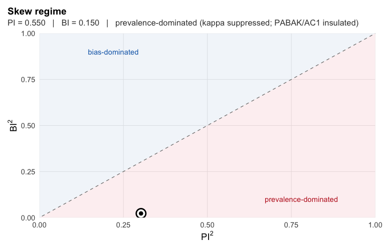

```r
plot(result, type = "regime")
```

skewed-examples.R

## Is the drift from N or from structure?

A natural question when you see a study plotted on a reference curve: the observed points land *off* the lines — is that because the sample is small, or because something structural is going on?

Short answer: **small N widens the scatter; prevalence drives the drift.** The two effects are separable, and you can see the separation directly. We compare the same data-generating process at small N vs large N, then the same small N at balanced vs skewed prevalence.

```r
# Helper: simulate two raters at Se = Sp = q against a latent truth.
draw <- function(n, p, q, seed = 1) {
  set.seed(seed)
  truth <- rbinom(n, 1, p)
  r1 <- ifelse(truth == 1, rbinom(n, 1, q), rbinom(n, 1, 1 - q))
  r2 <- ifelse(truth == 1, rbinom(n, 1, q), rbinom(n, 1, 1 - q))
  data.frame(r1 = r1, r2 = r2)
}
```

skewed-examples.R

### Same skew, different N

```r
r_small <- grass_report(draw(n =  50, p = 0.10, q = 0.85), reference = "high")
```

```
#> grass: `reference = 'high'` is deprecated. Use `spec = grass_spec_binary(reference_level = ...)` instead. This call's behaviour is unchanged.
```

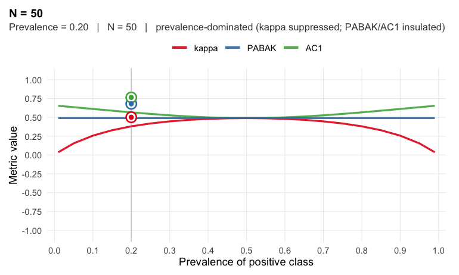

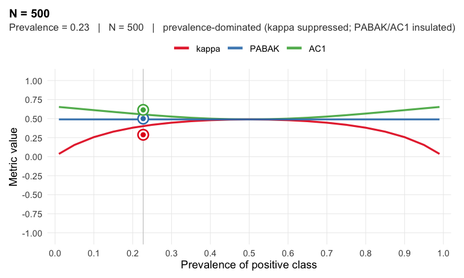

```r
r_large <- grass_report(draw(n = 500, p = 0.10, q = 0.85), reference = "high")
plot(r_small, labels = "legend") + ggplot2::labs(title = "N = 50")
plot(r_large, labels = "legend") + ggplot2::labs(title = "N = 500")
```

skewed-examples.R

### Same N, different prevalence

Now hold N = 50 constant but move prevalence from 0.10 (skewed) to 0.50 (balanced). At balanced prevalence the three metrics collapse toward each other and toward their reference curves. The earlier “kappa low, PABAK/AC1 high” pattern vanishes — it was a prevalence effect, not a noise effect.

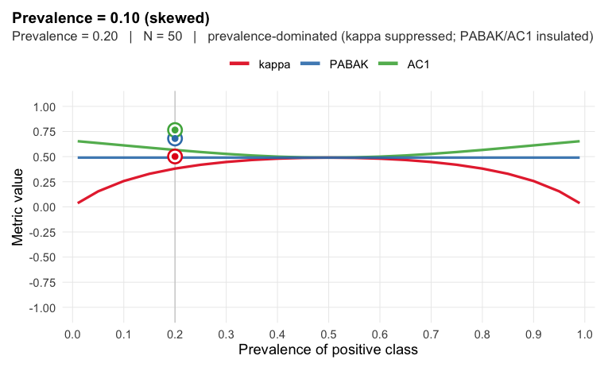

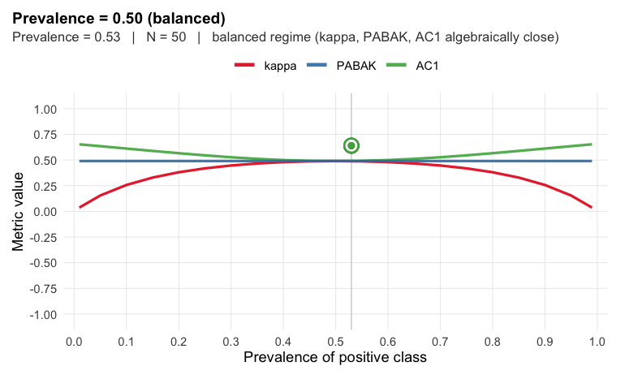

```r
r_skew <- grass_report(draw(n = 50, p = 0.10, q = 0.85), reference = "high")
r_bal  <- grass_report(draw(n = 50, p = 0.50, q = 0.85), reference = "high")
plot(r_skew, labels = "legend") + ggplot2::labs(title = "Prevalence = 0.10 (skewed)")
plot(r_bal,  labels = "legend") + ggplot2::labs(title = "Prevalence = 0.50 (balanced)")
```

skewed-examples.R

### Takeaway

When the three metrics land in visibly different positions relative to their reference curves, that is the algebra of the prevalence regime — not a signal that you need more data. Increasing N will tighten each point toward its own reference, but it will not line them up with each other. Report all three with PI, BI, and the regime label, and the reader can tell which effect is which.

## What to report

Always together:

1. Cohen’s κ (with a CI that respects the `[-1, 1]` bound at small N)
2. PABAK
3. Gwet’s AC1
4. Prevalence index (PI)
5. Bias index (BI)
6. The regime label

`grass_format_report(result)` produces a one-line version of the same information suitable for pasting into a manuscript sentence or a results table cell.